# Machine Learning (second part): Intermediate report

*Write your name and your student ID below.*

```python
# Modify these lines.
student_name = 'Xu Hongkun'
student_id = '20M31378'
```

Prepare an environment for running Python codes on Jupyter notebook. The most easiest way is to use [Google Colaboratory](https://colab.research.google.com/).

Write codes for the following four problems, and submit the notebook file (`.ipynb`) on OCW. **We do not accept a report in other formats (e.g., Word, PDF, HTML)**. You can use any deep learning library for completing this report. Write a code at the specified cell in the notebook. You can add more cells if necessary. Submit this report even if you cannot solve all problems.

These are the links to the sample codes used in the lecture:

- [Binary classification](https://github.com/chokkan/deeplearning/blob/master/notebook/binary.ipynb)
- [MNIST](https://github.com/chokkan/deeplearning/blob/master/notebook/mnist.ipynb)

*Please accept that your report may be shared among students who take this course.*

## 1. Multi-class classification on MNIST

Train a model on the training set of MNIST, and report the performance of the model on the test set in accuracy.

One can use the same code shown in the lecture. Write a code here and show the output.

```python
import torch
import torch.nn as nn

import torchvision
import torchvision.transforms as transforms

import numpy as np
import matplotlib.pyplot as plt
```

```python
#device = torch.device("cpu") # Uncomment this to run on CPU
device = torch.device("cuda:0")
```

### Extract, Transform, Load

```python
# Extract and Transform
train_set = torchvision.datasets.MNIST(
    root=r'./Dataset',
    train=True,
    download=True,
    transform=transforms.Compose([
        transforms.ToTensor()
    ])
)

test_set = torchvision.datasets.MNIST(
    root=r'./Dataset',
    train=False,
    download=True,
    transform=transforms.Compose([
        transforms.ToTensor()
    ])
)

# Load
train_loader = torch.utils.data.DataLoader(
    train_set,
    batch_size = 100,
    shuffle = True  # to have the data reshuffled at every epoch
)

test_loader = torch.utils.data.DataLoader(
    test_set,
    batch_size = 100,
    shuffle = False
)
```

```python
batch = next(iter(train_loader))
images, labels = batch
print(images.shape,'\t',labels.shape)
```

```
torch.Size([100, 1, 28, 28]) 	 torch.Size([100])
```

```
labels: tensor([[6, 4, 9, 5, 9, 3, 4, 0, 6, 4],
        [3, 4, 7, 9, 4, 9, 1, 7, 7, 4],
        [9, 1, 2, 6, 6, 2, 5, 4, 7, 2],
        [0, 8, 4, 4, 7, 5, 1, 1, 1, 4],
        [3, 1, 6, 2, 1, 2, 4, 3, 9, 5],
        [1, 4, 8, 0, 9, 7, 2, 8, 0, 9],
        [3, 1, 5, 5, 7, 1, 7, 0, 1, 8],
        [6, 8, 1, 2, 2, 8, 7, 6, 2, 2],
        [4, 5, 7, 1, 6, 9, 7, 1, 0, 8],
        [4, 1, 9, 6, 6, 5, 2, 8, 4, 2]])
```

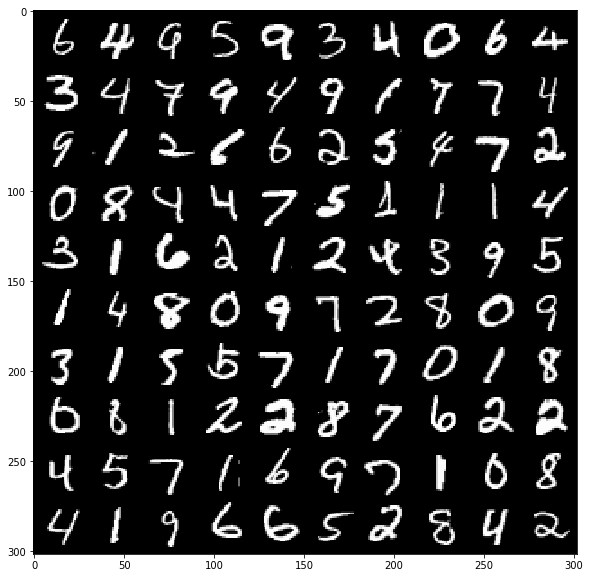

```python
grid = torchvision.utils.make_grid(images, nrow=10) # nrow：Number of images per row

plt.figure(figsize=(10,10)) # figure size
plt.imshow(np.transpose(grid, (1,2,0)))

print('labels:', labels.reshape(10,10))
```

### Create Network

```python
class ConvNetwork(nn.Module):
    def __init__(self):
        super(ConvNetwork, self).__init__()
        self.conv1 = nn.Conv2d(in_channels=1, out_channels=6, kernel_size=5, stride=1, padding=0)
        self.conv2 = nn.Conv2d(in_channels=6, out_channels=12, kernel_size=3, stride=1, padding=1)

        self.fc1 = nn.Linear(in_features=12*6*6, out_features=120)
        # self.fc2 = nn.Linear(in_features=120, out_features=60)
        self.out = nn.Linear(in_features=120, out_features=10)

    def forward(self, d):
        # conv1 layer
        d = self.conv1(d)
        d = nn.functional.relu(d)
        d = nn.functional.max_pool2d(d, kernel_size=2, stride=2)

        # conv2 layer
        d = self.conv2(d)
        d = nn.functional.relu(d)
        d = nn.functional.max_pool2d(d, kernel_size=2, stride=2)

        # fully connected Layer1
        # d = d.reshape(-1, 12*4*4)
        d = d.flatten(start_dim=1)
        d = self.fc1(d)
        d = nn.functional.relu(d)

        # fully connected Layer2
        # d = self.fc2(d)
        # d = nn.functional.relu(d)

        # output layer
        d = self.out(d)
        # d = nn.functional.softmax(d)

        return d
```

```python
network = ConvNetwork()
network.to(device)
```

```
ConvNetwork(
  (conv1): Conv2d(1, 6, kernel_size=(5, 5), stride=(1, 1))
  (conv2): Conv2d(6, 12, kernel_size=(3, 3), stride=(1, 1), padding=(1, 1))
  (fc1): Linear(in_features=432, out_features=120, bias=True)
  (out): Linear(in_features=120, out_features=10, bias=True)
)
```

### Activate TensorBoard

```python
%load_ext tensorboard
%tensorboard --logdir ./runs/ --port=6006
```

```
Reusing TensorBoard on port 6006 (pid 14576), started 0:28:23 ago. (Use '!kill 14576' to kill it.)
```

[interactive chart not shown]

### Train

```python
import torch.optim as optim

from torch.utils.tensorboard import SummaryWriter
```

```python
def test_model(model, loss_fn, test_loader, device=torch.device("cpu")):
    model.eval()

    loss = 0.
    num_correct = 0.

    for batch_idx, (x, y) in enumerate(test_loader):
        x, y = x.to(device), y.to(device)
        y_pred = model(x)
        loss += loss_fn(y_pred, y).item()
        _, predicted = torch.max(y_pred.data, 1)
        num_correct += (predicted == y).sum().item()

    model.train()

    loss /= len(test_loader.dataset)
    num_correct /= len(test_loader.dataset)

    return loss, num_correct
```

```python
def get_num_correct(preds, labels):
    '''
    Calculate the number of correct predictions
    '''
    return preds.argmax(dim=1).eq(labels).sum().item()
```

```python
# Learning Rate
lr = 0.008

loss_function = nn.CrossEntropyLoss()
optimizer = optim.SGD(network.parameters(), lr=lr)

# tensorboard
tb = SummaryWriter(comment="My CNN")

# images, labels = next(iter(train_loader))
# gird = torchvision.utils.make_grid(images)
# tb.add_images('images', grid)
# tb.add_graph(network, images)

# Training times
for epoch in range(10):
    train_loss = 0
    train_correct = 0

    for batch in train_loader:
        images, labels = batch
        images, labels = images.to(device), labels.to(device)

        # forward
        preds = network(images)

        # Compute the loss value.
        loss = loss_function(preds, labels)
        train_loss += loss.item()
        train_correct += get_num_correct(preds, labels)

        # Update the weights
        optimizer.zero_grad()  # Initialize to zero.
        loss.backward()
        optimizer.step()       # Updating the weights


    # Compute the average loss and accuracy.
    train_loss /= len(train_set)
    train_correct /= float(len(train_set))

    # Evaluate the model on the test set.
    test_loss, test_correct = test_model(network, loss_function, test_loader, device)

    # Record loss and accuracy values on the training and test sets.
    tb.add_scalars('loss', {'train': train_loss, 'test': test_loss}, epoch)
    tb.add_scalars('accuracy', {'train': train_correct, 'test': test_correct}, epoch)

    # Report progress
    print(f'#{epoch}: loss_test={test_loss:.4f}, loss_train={train_loss:.4f}, acc_test={test_correct:.4f}, acc_train={train_correct:.4f}')


# Don't forget it!
tb.close()
```

```
#0: loss_test=0.0217, loss_train=0.0227, acc_test=0.3534, acc_train=0.2314
#1: loss_test=0.0044, loss_train=0.0103, acc_test=0.8665, acc_train=0.7210
#2: loss_test=0.0033, loss_train=0.0040, acc_test=0.8997, acc_train=0.8771
#3: loss_test=0.0026, loss_train=0.0030, acc_test=0.9165, acc_train=0.9073
#4: loss_test=0.0019, loss_train=0.0024, acc_test=0.9425, acc_train=0.9257
#5: loss_test=0.0017, loss_train=0.0020, acc_test=0.9489, acc_train=0.9382
#6: loss_test=0.0015, loss_train=0.0018, acc_test=0.9529, acc_train=0.9465
#7: loss_test=0.0013, loss_train=0.0016, acc_test=0.9602, acc_train=0.9515
#8: loss_test=0.0012, loss_train=0.0014, acc_test=0.9637, acc_train=0.9573
#9: loss_test=0.0012, loss_train=0.0013, acc_test=0.9622, acc_train=0.9592
```

### Save (only its state dict)

```python
torch.save(network.state_dict(), './network.pt')
# network_state_dict = torch.load('./network.pt')
# new_network = ConvNetwork()
# new_network.load_state_dict(network_state_dict)
```

## 2. Confusion matrix

Show a confusion matrix of the predictions of the model on the test set. This is an example of a confusion matrix.

[figure not shown]

Write a code here and show the confusion matrix.

```python
cmt = torch.zeros(10,10, dtype=torch.int32)
cmt.to(device)
print(cmt)
```

```
tensor([[0, 0, 0, 0, 0, 0, 0, 0, 0, 0],
        [0, 0, 0, 0, 0, 0, 0, 0, 0, 0],
        [0, 0, 0, 0, 0, 0, 0, 0, 0, 0],
        [0, 0, 0, 0, 0, 0, 0, 0, 0, 0],
        [0, 0, 0, 0, 0, 0, 0, 0, 0, 0],
        [0, 0, 0, 0, 0, 0, 0, 0, 0, 0],
        [0, 0, 0, 0, 0, 0, 0, 0, 0, 0],
        [0, 0, 0, 0, 0, 0, 0, 0, 0, 0],
        [0, 0, 0, 0, 0, 0, 0, 0, 0, 0],
        [0, 0, 0, 0, 0, 0, 0, 0, 0, 0]], dtype=torch.int32)
```

```python
# all prediction on test dataset
all_preds = torch.tensor([])
all_preds = all_preds.to(device)

# softmax function
softmax = nn.Softmax(dim=1)

with torch.no_grad():
    for batch in test_loader:
        images, labels = batch
        images, labels = images.to(device), labels.to(device)

        preds = network(images)
        all_preds = torch.cat((all_preds, preds), dim=0)

    #  calculate the conditional probability
    all_preds = softmax(all_preds)
```

```python
# The one with the highest conditional probability of prediction.
all_preds_probability, all_preds_No = all_preds.max(dim=1)
```

```python
# [[label1, pred1],
#  [label2, pred2],
#    ...
#  [labeln, predn]]

stacked = torch.stack((test_set.targets.to(device), all_preds_No), dim=1)
```

```python
for item in stacked:
    label, pred = item.tolist()
    cmt[label, pred] += 1
```

```python
cmt
```

```
tensor([[ 971,    0,    1,    1,    2,    1,    1,    1,    2,    0],
        [   0, 1115,    4,    0,    0,    0,    2,    1,   13,    0],
        [   5,    0, 1003,    5,    1,    0,    4,    5,    9,    0],
        [   2,    2,    9,  954,    1,   11,    0,    5,   22,    4],
        [   0,    0,    4,    0,  943,    0,    2,    1,    4,   28],
        [   6,    3,    1,    9,    4,  835,    8,    1,   20,    5],
        [   7,    3,    8,    0,    8,    4,  923,    1,    4,    0],
        [   0,    7,   15,    3,    5,    0,    0,  966,    3,   29],
        [   7,    0,    1,    3,    3,    2,    2,    2,  949,    5],
        [   4,    7,    0,    6,   14,    0,    1,    6,    8,  963]],
       dtype=torch.int32)
```

### Plot a Confusion matrix

```python
import seaborn as sns
```

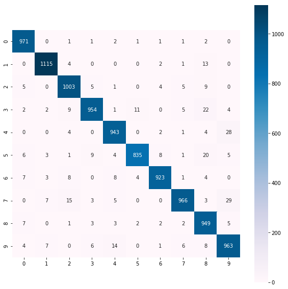

```python
f, ax = plt.subplots(figsize=(10, 10))
sns.heatmap(cmt, annot=True, fmt='d', square=True, cmap="PuBu")
plt.show()
```

## 3. Top-3 easy and confusing examples

Show the top three easy and three confusing, respectively, images where the model recognized their digits with strong confidences. More specifically, let $y_n$ and $\hat{y}_n$ the true and predicted, respectively, digits of the image $x_n$. We want to find three images with high $P(\hat{y}_n | x_n)$ when $y_n = \hat{y}_n$ (for easy three examples) and $y_n \neq \hat{y}_n$ (for confusing three examples).

For each example, please show $y_n$, $P(y_n | x_n)$, $\hat{y}_n$, and $P(\hat{y}_n | x_n)$ together with the image $x_n$. This is an example of an output for an image (you need this kind of outputs for top-three easy and top-three confusing images, in other words, for six images in total).

[figure not shown]

Write a code here and show the output.

```python
# all_preds: [10000, 10]
# all_preds_probability: [10000]
# stacked: [10000, 2]

import copy

with torch.no_grad():
    temp_Prob = copy.deepcopy(all_preds_probability)

    # top 3 easy one
    top_Easy = []
    # top 3 confusing one
    top_Confusing = []

    while temp_Prob.max().item()!=-1 and len(top_Easy) < 3 or len(top_Confusing) < 3:

        index = temp_Prob.argmax()

        if stacked[index][0] == stacked[index][1] and len(top_Easy) < 3:
            y_label = stacked[index][0].item()
            y_label_Prob = all_preds[index][y_label].item()
            y_pred = stacked[index][1].item()
            MaxProb = temp_Prob.max().item()
            top_Easy.append([index,y_label, y_label_Prob, y_pred, MaxProb])

        if stacked[index][0] != stacked[index][1] and len(top_Confusing) < 3:
            y_label = stacked[index][0].item()
            y_label_Prob = all_preds[index][y_label].item()
            y_pred = stacked[index][1].item()
            MaxProb = temp_Prob.max().item()
            top_Confusing.append([index,y_label, y_label_Prob, y_pred, MaxProb])

        temp_Prob[index] = -1
```

### Top-3 Easy example

```
True digit: 2 (0.9999997615814209); Prediction: 2 (0.9999997615814209)
```

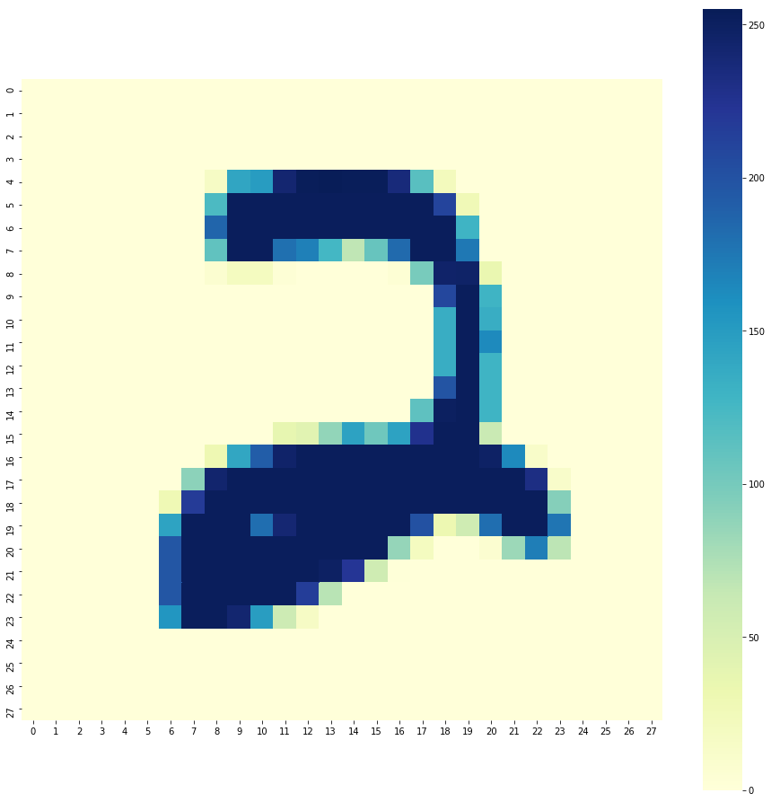

```
True digit: 2 (0.9999997615814209); Prediction: 2 (0.9999997615814209)
```

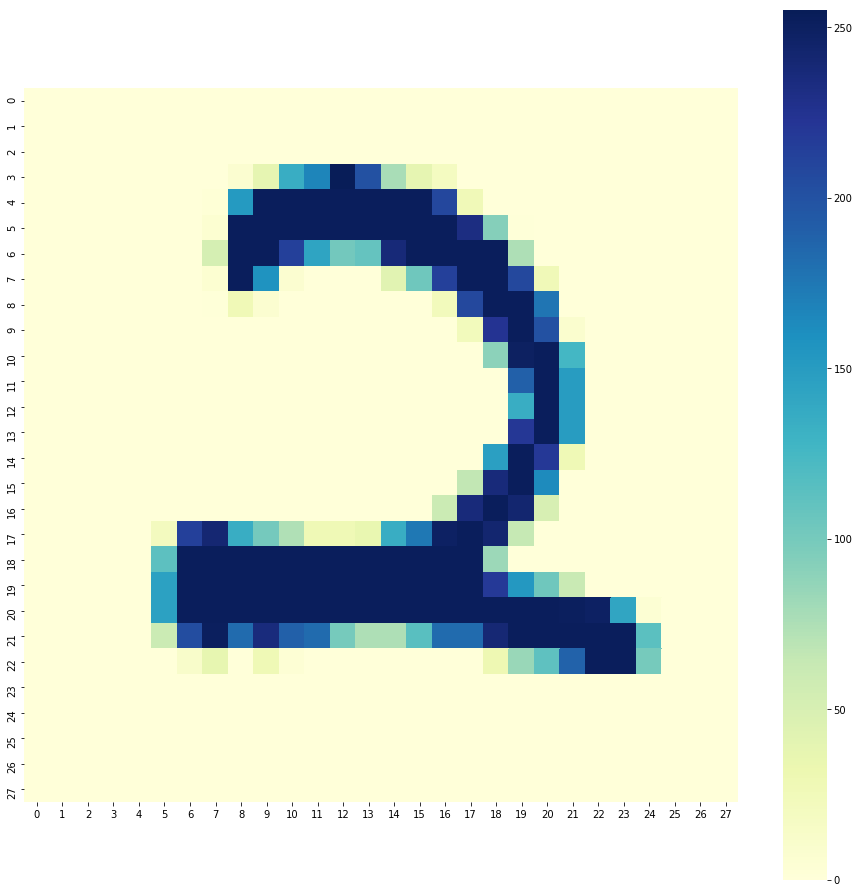

```
True digit: 2 (0.9999997615814209); Prediction: 2 (0.9999997615814209)
```

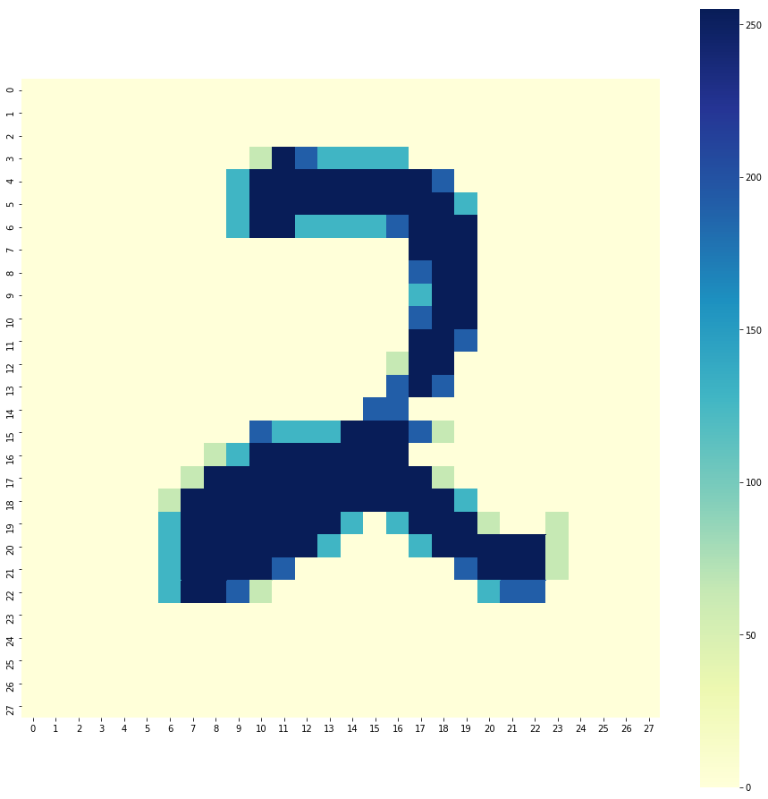

```python
for item in top_Easy:

    print(f"True digit: {item[1]} ({item[2]}); Prediction: {item[3]} ({item[4]}) ")

    plt.subplots(figsize=(16, 16))
    image = test_set.data[item[0]]
    sns.heatmap(image, square=True, cmap="YlGnBu")
    plt.show()
```

### Top-3 Confusing example

```
True digit: 7 (0.0001285486650886014); Prediction: 2 (0.9993895292282104)
```

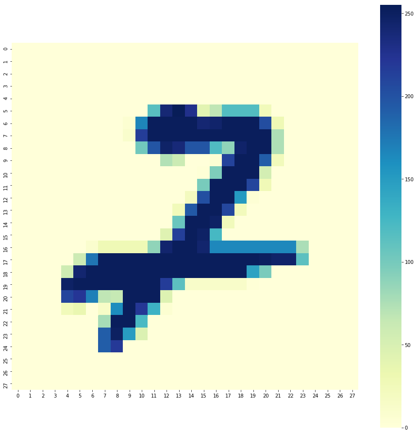

[output not shown]

[figure not shown]

```
True digit: 7 (6.462898454628885e-05); Prediction: 2 (0.9955106973648071)
```

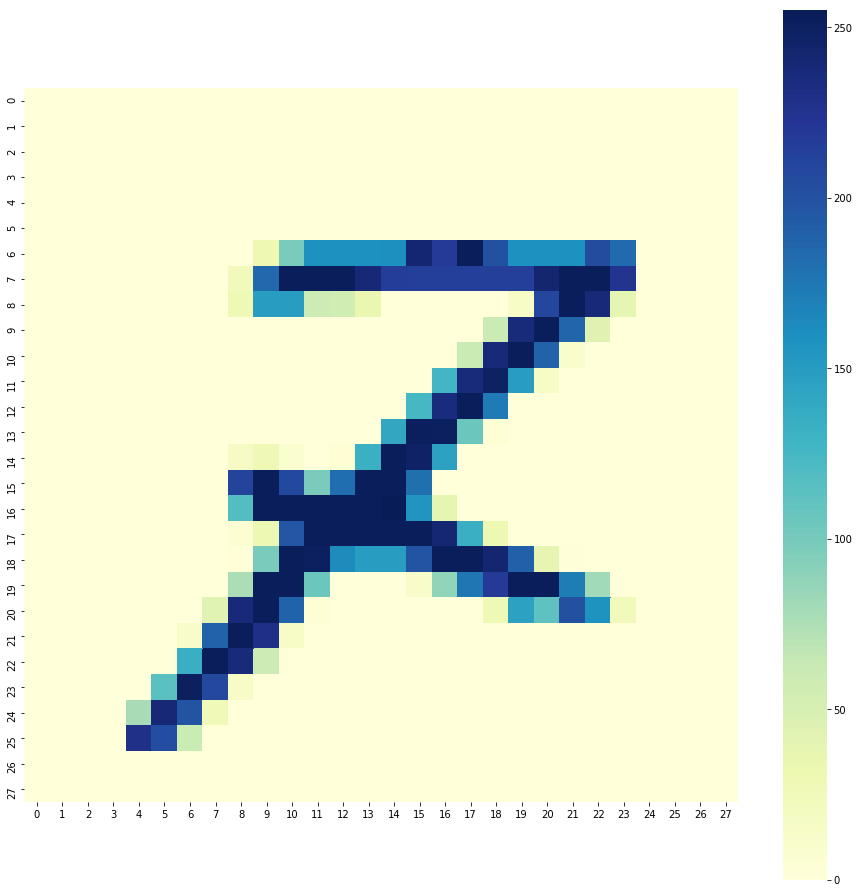

```python
for item in top_Confusing:

    print(f"True digit: {item[1]} ({item[2]}); Prediction: {item[3]} ({item[4]}) ")

    plt.subplots(figsize=(16, 16))
    image = test_set.data[item[0]]
    sns.heatmap(image, square=True, cmap="YlGnBu")
    plt.show()
```

## 4. Recognize your handwritten digits

Prepare three image files each of which presents a digit written by you. For each image, apply the MNIST model you trained, and show the probability estimate $\hat{y} \in \mathbb{R}^{10}$ (10-dimensional vector) for all possible digits as well as the image itself.

Please refer to [this notebook](https://colab.research.google.com/notebooks/io.ipynb) about how to upload a file to Google Colaboratory.

### Image #1

Write the code to show the image #1 here.

```python
from PIL import Image
import urllib
```

```python
# Convert to tensor
to_tensor = transforms.Compose([
    transforms.Resize((28,28)),  # Resize the input image
    transforms.Grayscale(),      # Convert image to grayscale.
    transforms.ToTensor()        # Converts a PIL Image in the range [0, 255] to a torch. FloatTensor in the range [0.0, 1.0].
])
```

```python
def Predict(img):
    '''
    Prediction and display
    '''
    with torch.no_grad():
        img_tensor = to_tensor(img)

        # boardcasting
        img_tensor = 1 - img_tensor.squeeze()

        input_data =  img_tensor.unsqueeze(dim=0)
        input_data = input_data.unsqueeze(dim=0)
        input_data = input_data.to(device)

        # forward
        preds = network(input_data)
        preds = softmax(preds)
        prediction = preds.argmax(dim=1).item()
        probability = preds[0].tolist()

        # output
        print(f"Prediction: {prediction}")
        print("Probability: [{:.4f}，{:.4f}，{:.4f}，{:.4f}, {:.4f}, {:.4f}, {:.4f}, {:.4f}, {:.4f}, {:.4f}]".format(
            probability[0],
            probability[1],
            probability[2],
            probability[3],
            probability[4],
            probability[5],
            probability[6],
            probability[7],
            probability[8],
            probability[9]
        ))

        sns.heatmap(img_tensor, square=True, cmap="YlGnBu")
        plt.show()
```

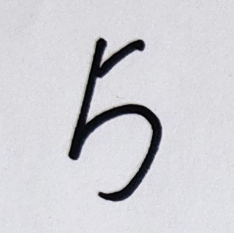

```python
digit_URL1 = 'https://raw.githubusercontent.com/birdtianyu/Handwriting/master/images/Handwriting_images/Handwriting1.jpg'

img1 = Image.open(urllib.request.urlopen(digit_URL1))
img1
```

Write the code to show the probability estimate $\hat{y} \in \mathbb{R}^{10}$ for the image.

```python
torch.set_printoptions(linewidth=120)
```

```
Prediction: 5
Probability: [0.0036，0.0001，0.0168，0.0495, 0.0104, 0.4670, 0.0193, 0.0001, 0.4277, 0.0056]
```

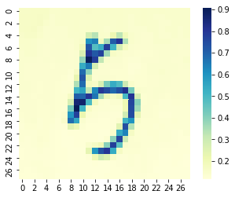

```python
Predict(img1)
```

### Image #2

Write the code to show the image #2 here.

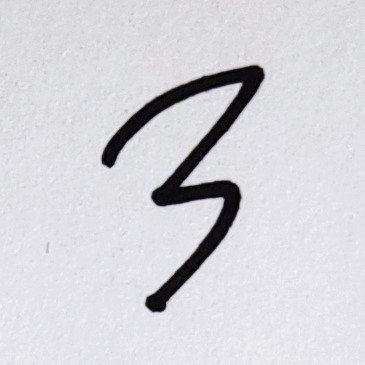

```python
digit_URL2 = 'https://raw.githubusercontent.com/birdtianyu/Handwriting/master/images/Handwriting_images/Handwriting3.jpg'

img2 = Image.open(urllib.request.urlopen(digit_URL2))
img2
```

Write the code to show the probability estimate $\hat{y} \in \mathbb{R}^{10}$ for the image.

```
Prediction: 3
Probability: [0.0001，0.0005，0.0112，0.6489, 0.0005, 0.0169, 0.0001, 0.0002, 0.3203, 0.0013]
```

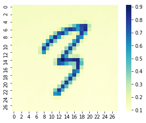

```python
Predict(img2)
```

### Image #3

Write the code to show the image #3 here.

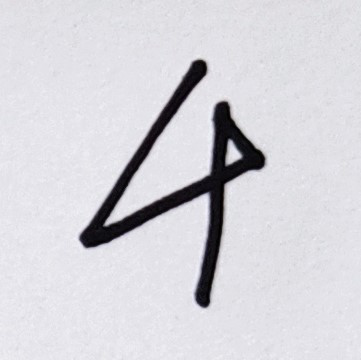

```python
digit_URL3 = 'https://raw.githubusercontent.com/birdtianyu/Handwriting/master/images/Handwriting_images/Handwriting4.jpg'

img3 = Image.open(urllib.request.urlopen(digit_URL3))
img3
```

Write the code to show the probability estimate $\hat{y} \in \mathbb{R}^{10}$ for the image.

```
Prediction: 8
Probability: [0.0082，0.0004，0.2277，0.1144, 0.1556, 0.0024, 0.0022, 0.0043, 0.3607, 0.1242]
```

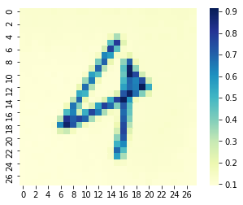

```python
Predict(img3)
```